# Final Project

Student 1: Paul Marie Mweni

Student 2: Jane Shadrina

Student 3: Moustafa Basiony

Student 4: Tolulope Soetan

2026-01-11

```r
library(quanteda)
library(quanteda.textmodels)
library(tidyverse)
library(stringr)
library(lubridate)
library(stopwords)
library(textstem)
library(quanteda)
library(quanteda.textstats)
library(quanteda.textplots)
library(forcats)
library(caret)
library(stringr)
library(lubridate)
library(stopwords)
library(forcats)
library(topicmodels)
library(topicdoc)
library(rJava)
library(mallet)
library(LDAvis)
library(servr)
library(reshape2)
library(ggthemes)
library(pROC)
```

# Introduction

Online platforms have become central arenas for the negotiation of gender, identity, and power. Among these platforms, Reddit hosts a wide range of communities dedicated to discussions of men’s issues, feminism, and contemporary gender politics. One such community is r/MensRights, a subreddit created in 2008 that defines itself as an advocacy space “for the social and legal equality of men and boys” and for discussion of “any issue related to the relationship of men to society.” While the stated focus of the subreddit emphasizes legal and social equality, previous research suggests that men’s rights communities are often embedded within the broader manosphere, a loose network of online groups that articulate shared narratives about masculinity, gender relations, and perceived discrimination against men (Chang, 2022).

The emergence of the manosphere is commonly understood as a response to the rise of feminism in the late twentieth century. Early men’s rights movements were frequently characterized by explicitly anti feminist rhetoric, framing feminism as a force that undermines men’s social status, legal rights, and cultural legitimacy (Messner, 2016). According to Messner (2016), such orthodox anti-feminist movements are less likely to be socially acceptable in the post feminist era, where overt misogyny is more readily sanctioned. As a consequence, a more moderate and neo liberal form of men’s rights discourse has gained prominence. This discourse does not always articulate explicit hostility toward feminism, but it implicitly assumes a feminist dominated social order and frames men as an overlooked or disadvantaged group within social and legal institutions.

Ging (2019) further distinguishes between these strands of men’s rights discourse. Orthodox anti feminist men’s rights groups tend to focus on issues such as domestic violence against men, child custody, divorce, and the feminisation of education, often articulated through grievance based and adversarial narratives. In contrast, neo liberal men’s rights discourse emphasizes men’s wellbeing and individual self improvement using a depoliticized language of equality, while still implicitly positioning feminism as the dominant ideological force (Ging, 2019; Messner, 2016). Although this distinction is well established theoretically, it remains unclear how these discourses are reflected in large scale online communities such as r/MensRights.

Hate speech plays a particularly important role in manosphere related spaces. Beyond isolated instances of offensive language, hateful expressions function as discursive tools that reinforce in group identity, legitimize hostility toward women and feminist movements, and normalize antagonistic gender ideologies (Ging, 2019). While existing scholarship has examined the prevalence of toxicity and misogyny in the manosphere, relatively little attention has been paid to the thematic content of hate speech itself, namely what users are actually discussing when they engage in hateful expression.

This study addresses these gaps by combining supervised machine learning and topic modeling to analyze discourse in r/MensRights. Hate speech is first identified using interpretable classification models trained on manually annotated data. Rather than treating hate speech solely as a classification outcome, the study conceptualizes it as a discursive phenomenon whose themes and narratives can reveal deeper ideological structures. Topic modeling is then applied to posts classified as hate speech in order to uncover the dominant themes articulated within this subset of content.

The study is guided by the following research questions:

· RQ1: What is the prevalence and distribution of hate speech within the r/MensRights subreddit?

· RQ2: What thematic patterns characterize hate speech within r/MensRights, and how do these themes relate to established manosphere narratives (Chang, 2022)?

· RQ3: To what extent does the discourse in r/MensRights aligns with an orthodox anti feminist men’s rights movement as opposed to a more moderate neo liberal men’s rights discourse, as described by Messner (2016) and Ging (2019)?

Based on the existing literature, the following hypotheses are proposed:

· H1: Hate speech constitutes a non marginal and systematically observable component of discourse within the r/MensRights subreddit.

· H2: The thematic structure of hate speech in r/MensRights is dominated by topics commonly associated with orthodox anti feminist men’s rights discourse, including domestic violence against men, child custody and divorce, and the feminisation of education (Ging, 2019).

· H3: Hate speech in r/MensRights is primarily organized around grievance based narratives, including claims of misandry, perceived female or feminist dominance, and the delegitimization of feminist movements, reflecting core manosphere frames (Chang, 2022; Ging, 2019).

To answer these questions, the study analyzes a large corpus of Reddit posts collected from r/MensRights over an extended period. By integrating supervised classification and unsupervised topic modeling, the analysis provides a systematic examination of how hate speech and men’s rights discourse are articulated in a prominent online community, thereby contributing to a deeper understanding of the manosphere and gender politics in digital spaces.

**Methodology**

This project answer the above research questions by combining supervised machine learning and topic modeling to analyze hate speech in r/MensRights. Rather than treating hate speech solely as a classification outcome, the study approaches it as a discursive phenomenon whose themes, narratives, and argumentative patterns can reveal deeper ideological structures.

The dataset consists of 46,365 Reddit posts collected via the Pushshift API, covering the period from June 2009 to November 2022. Prior to any modeling, the full corpus underwent systematic text preprocessing, including lowercasing, removal of punctuation, URLs, HTML artefacts, tokenization, stop-word removal, and lemmatization. We created multiple cleaned versions of the same posts to test the performance of different feature representations (unigram vs. unigram+bigram, lemmatized vs. non-lemmatized, etc.) under the same annotation scheme. This preprocessing pipeline ensured consistency across both the supervised and unsupervised stages of the analysis. To enable supervised classification, a multi-stage annotation and validation strategy was implemented. First, a subset of 300 posts was independently coded by four annotators to assess intercoder reliability. All coders were trained using a shared theoretical framework and discussed relevant categories prior to annotation, after which agreement was evaluated using pairwise Cohen’s kappa coefficients.

Following this calibration phase, a larger sample of 1,200 posts was manually annotated to serve as the labeled dataset for model training and testing. This dataset exhibited moderate class imbalance, with 717 posts labeled as non–hate speech and 483 labeled as hate speech. These annotations were used to train and evaluate multiple interpretable classifiers, including logistic regression, naïve Bayes, and random forest models. Model performance was assessed using precision, recall, F1-score, balanced accuracy, and agreement statistics, with particular emphasis placed on recall for the hate-speech class to maximize the inclusion of relevant content for downstream analysis.

To further assess the reliability of automated classification, an additional validation sample of 300 posts was drawn from the automatically labeled corpus and manually reviewed. This step provided an external quality check on model predictions, allowing for an estimation of false positives and false negatives before proceeding to large-scale thematic analysis.

Posts predicted as hate speech were then subjected to Latent Dirichlet Allocation (LDA) topic modeling.

Ultimately, this project seeks to contribute to a more nuanced understanding of how hate speech functions within online gender-politics communities. By mapping the thematic landscape of hateful discourse in r/MensRights, it aims to clarify the extent to which this subreddit reflects broader manosphere narratives such as misandry claims, perceived female dominance, and anti-feminist ideology, and to demonstrate the value of mixed-method approaches for studying complex social phenomena in digital spaces.

## EDA and Preprocessing

Our data was imported using the reddit API in python.

The dataset contains six columns: author, date, title, selftext, reddit_label, and year.

1. **author:** the username of the author of the text in the subreddit.
2. **date:** the date of publication of the post.
3. **selftext:** the original text of the post.
4. **reddit_label:** the label automatically assigned to the post by reddit. This feature was introduced around 2014. Thus, posts published before 2014 do not have a label. We could consider the label to be the topics. We assume that the labels automatically assigned by Reddit is not depth enough and does not allow us to capture the full meaning of the post.
5. **year:** year the post was published

### Cleaning

In order to use the data, we first need to clean our text, as raw Reddit posts contain a lot of noise — including URLs, HTML artifacts, formatting symbols, and punctuation — which can negatively affect the analysis. We therefore apply a conservative cleaning procedure that only removes formatting and boilerplate elements using regular expressions. Specifically, we:

- Convert markdown links of the form text to just text
- Remove all URLs
- Strip HTML tags and escape sequences
- Remove backticks and other formatting symbols
- Remove punctuation, special characters, and emojis while keeping letters, numbers, spaces, apostrophes, underscores, and hyphens
- Collapse multiple spaces and convert all text to lowercase

This procedure preserves the core textual content while removing elements that could introduce noise into the topic modeling.

```r
# loading the dataset
cleanmenright <- read_csv('/Users/PaulMUTAMBA/Documents/Old Pc/HSE Social Info/Third Year/Text Analysis/cleanmenright.csv')
raw_dataset <- cleanmenright %>% as_tibble()

# making a single text_raw field that contains both title and selftext
posts <- raw_dataset %>%
  dplyr::select(any_of(c("author","date","title","selftext","reddit_label","year","wspaceselftext"))) %>%
  mutate(id = row_number(), date_parsed = suppressWarnings(mdy(date)), year = if_else(!is.na(year), as.integer(year), as.integer(year(date_parsed))), title = coalesce(as.character(title), ""), selftext = coalesce(as.character(selftext), ""), reddit_label = na_if(as.character(reddit_label), ""), text_raw = str_squish(str_c(title, selftext, sep = " "))) %>%
  filter(text_raw != "")

# building the cleaning function
clean_regex <- function(x) {x %>%
    str_replace_all("\\[([^\\]]+)\\]\\((https?://[^\\)]+)\\)", "\\1") %>% # [txt](url) -> txt
    str_replace_all("https?://\\S+|www\\.\\S+", " ") %>% # turning URLs -> ""
    str_replace_all("</?\\w[^>]*>", " ") %>% # HTML tags -> ""
    str_replace_all("&[^;]+;", " ") %>% # HTML escapes -> ""
    str_replace_all("`{1,3}", " ") %>% # backticks -> ""
    str_replace_all("[^\\p{L}\\p{N}\\s'_-]+", " ") %>% # symbols/punctuation/emoji -> ""
    str_squish() %>% # removing extra whitespaces
    str_to_lower()} # lowercase everything

posts <- posts %>%
  mutate(text_clean = clean_regex(text_raw)) %>%
  filter(text_clean != "")
```

Next we inspect our cleaned posts to validate and assess the scale and variability of the dataset.

```r
posts <- posts %>% mutate(n_chars = str_length(text_clean), n_words = str_count(text_clean, boundary("word")))

diag_tbl <- tibble(metric = c("Observations:", "Mean characters (clean):", "Mean words per text (clean):", "Median words (clean):", "90% of posts are at or below (clean): ", "Date range (parsed):"),
  value = c(nrow(posts), round(mean(posts$n_chars), 2), round(mean(posts$n_words), 2), round(median(posts$n_words), 2), round(quantile(posts$n_words, 0.90), 2), paste0(min(posts$date_parsed, na.rm=TRUE), " to ", max(posts$date_parsed, na.rm=TRUE))))

print(diag_tbl)
```

```
## # A tibble: 6 × 2
##   metric                                   value
##   <chr>                                    <chr>
## 1 "Observations:"                          44414
## 2 "Mean characters (clean):"               1236.91
## 3 "Mean words per text (clean):"           228.09
## 4 "Median words (clean):"                  131
## 5 "90% of posts are at or below (clean): " 505
## 6 "Date range (parsed):"                   2009-06-19 to 2022-11-19
```

**Interpretation and implications for further steps:**

There are 44414 observations in our dataset and it spans from 19/06/2009 to 19/11/2022.

### Distribution of posts over years:

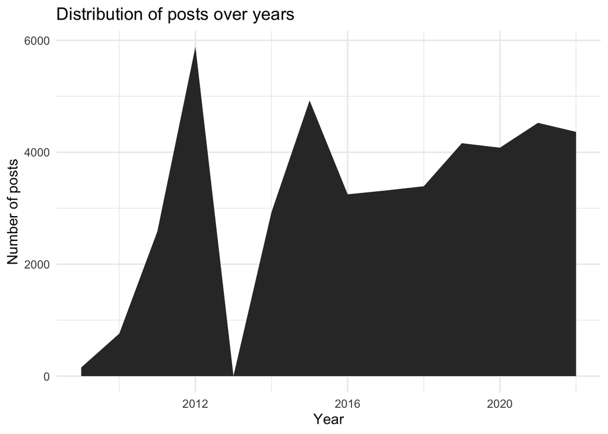

```r
posts %>% filter(!is.na(year)) %>% count(year) %>%
  ggplot(aes(x = year, y = n)) +
  geom_area() +
  labs(title = "Distribution of posts over years",
       x = "Year", y = "Number of posts") +
  theme_minimal(base_size = 12)
```

The dataset contains posts from 2009 to 2022. In 2013, the sub-credit was closed due to controversial cases, which explains the sharp decrease in messages that year.

### Tokenization, stopwords

Next, we are removing standard stopwords (except negations) and performing tokenization. We are deliberatly keeping negation words (not/no/nor), because within the scope of our research question, they are important contextual cues (in cases of denial, negated accusations, taking positions, etc.)

```r
sw <- stopwords("en")
sw <- setdiff(sw, c("no", "nor", "not"))
corp <- corpus(posts, text_field = "text_clean")
docvars(corp, "year") <- posts$year
toks <- quanteda::tokens(corp, remove_punct = TRUE, remove_numbers = TRUE, remove_symbols = TRUE, remove_separators = TRUE) %>%
  tokens_tolower() %>%
  tokens_remove(sw) %>%
  tokens_select(pattern = "^[a-z][a-z']{1,}$", valuetype = "regex", selection = "keep")
dfm_uni <- dfm(toks)
```

### Word frequencies & wordcloud

```r
top_tbl <- tibble(term = names(topfeatures(dfm_uni, 30)), freq = as.integer(topfeatures(dfm_uni, 30)))

top_tbl
```

```
## # A tibble: 30 × 2
##    term    freq
##    <chr>  <int>
##  1 men    76443
##  2 women  65991
##  3 not    64858
##  4 just   35012
##  5 like   31390
##  6 can    29927
##  7 one    24886
##  8 get    24462
##  9 people 24351
## 10 no     24140
## # ℹ 20 more rows
```

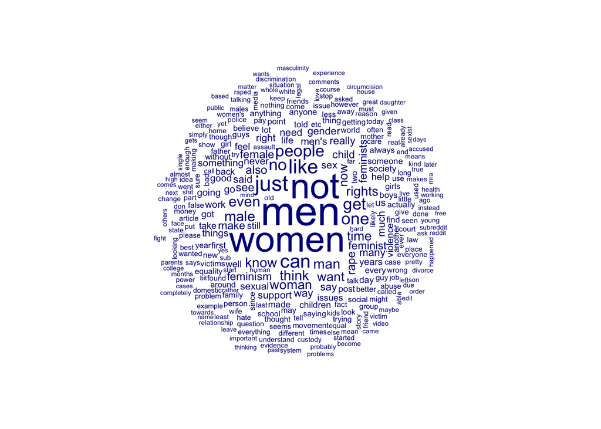

```r
textplot_wordcloud(dfm_uni, max_words = 300)
```

As we can see, both “men” and “women” are in top terms, as well as “rights”, “feminism/feminist(s)”, “rape”, and also “not” (we intentionally kept negations). This is consistent with our expectations: a big share of posts revolves around gender categories, ideology, and conflict domains (like sexual violence discourse).

### Collocations

Next we look at which words pairs occur together more often than expected given their marginal frequencies:

```r
coll <- textstat_collocations(toks, size = 2, min_count = 25) %>% arrange(desc(lambda))

print(head(coll, 15))
```

```
##               collocation count count_nested length   lambda        z
## 7135      referrals usccr    39            0      2 17.04292 11.78931
## 4425          los angeles    86            0      2 16.94325 19.45795
## 2698         saudi arabia   111            0      2 15.95779 27.02238
## 2575           boko haram    75            0      2 15.88298 27.61922
## 7450      daniel levinson    56            0      2 15.81755 11.09916
## 7553          murphey doj    32            0      2 15.57231 10.87939
## 7564        debra murphey    32            0      2 15.53691 10.85632
## 7598          cidhoea oas    26            0      2 15.44302 10.76710
## 7599            spcim oas    26            0      2 15.44302 10.76710
## 4001          sonja starr    25            0      2 15.21097 21.10975
## 7828         askdoj usdoj    53            0      2 14.62538 10.28291
## 5006        san francisco    61            0      2 14.60066 17.52971
## 2206       camille paglia    34            0      2 14.37286 29.73834
## 7939 racketeer influenced    29            0      2 14.37084 10.06192
## 5132      scheme artifice    45            0      2 14.33230 17.13261
```

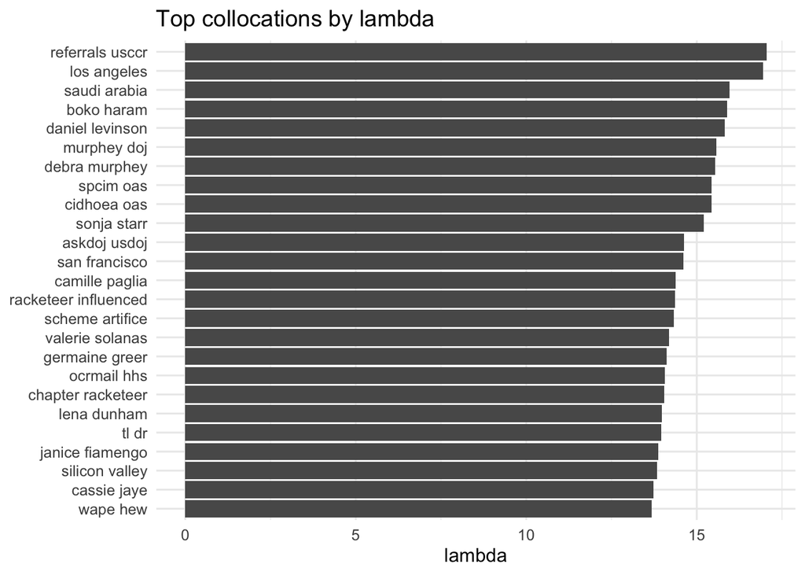

```r
coll %>% slice_head(n = 25) %>% mutate(collocation = fct_reorder(collocation, lambda)) %>%
  ggplot(aes(x = lambda, y = collocation)) +
  geom_col() +
  labs(title = "Top collocations by lambda", x = "lambda", y = NULL) +
  theme_minimal(base_size = 12)
```

The top collocations are things like “los angeles”, “saudi arabia”, “boko haram”, as well as name-like pairs (“daniel levinson”, “camille paglia”, etc.) It implies that a part of r/MensRights posts comments on specific cases, certain locations, and public figures.

## Supervised ML

To investigate the prevalence and patterns of hate speech in r/MensRights, and therefore answer the **RQ1**, we decided to use a supervised machine learning approach.

### Code Dataset

```r
labelled <- readxl::read_excel("/Users/PaulMUTAMBA/Downloads/Labelled_Posts.xlsx")
cleaned <- read_csv('/Users/PaulMUTAMBA/Downloads/mensrights_text_variants_for_ml.csv')
```

To predict hate speech within our corpus, we utilize machine learning models trained on a custom labeled dataset, as existing resources predominantly focus on **explicit misogyny**—characterized by open attacks, insults, or threats. The necessity for a more nuanced dataset is illustrated by the evolution of the “Men’sRights” subreddit; following a shadow ban in 2013 due to controversial content, moderators deleted posts containing explicit hate speech to comply with Reddit policies. However, this suppression did not eliminate the hostility but rather caused it to evolve into **implicit misogyny**, where members used linguistic creativity to bypass detection. To capture this shift, we sampled and coded 1,200 posts based on the classification scheme by Strathern and Pfeffer (2022), which identifies eleven distinct layers of online misogyny. This scheme defines **explicit misogyny** through four categories: **call for action/violence** (inciting physical punishment or institutionalization), **personal insult** (using slurs and defamation), **gendered personal attacks** (leveraging stereotypes or sexual motivation), and **intellectual inferiority** (judging women moral or intellectual worth). To address the “hidden” hate found in groups like the Men’sRights subreddit, the scheme also incorporates seven layers of **implicit misogyny**: **cynicism/sarcasm** (derogatory attitudes requiring context), **skeptical attitude/distrust** (undermining accounts), **imputation** (flawed motivations like being “attention-seeking”), **allegation** (refuting accounts with “facts”), **speculation/denying credibility** (doubting the severity of experiences), **demonstration of power** (supporting the male counterpart), and **taking a position** (redefining the perpetrator and victim). To these, we added the category of **men’s grievance**, which we adapted from the definition of “white grievance” provided by ElSherief et al. (2021) . Just as white grievance involves frustration over a minority group’s perceived privilege and the casting of majority groups as the “real victims” of social change, men’s grievance frames men as the primary victims of gender equality or “misandry”.

Therefore for our study, **hate speech** is defined as a gender-based antagonistic discourse that includes both **explicit** and **implicit** misogyny including **male grievance** narratives.

#### Inter-coder Reliability

```r
paul <- readxl::read_excel('/Users/PaulMUTAMBA/Documents/Old Pc/KUL QASS/Collecting and Analysing for SDS/com_sample_posts(AutoRecovered).xlsx')
jane <- read_csv("/Users/PaulMUTAMBA/Documents/Old Pc/KUL QASS/Collecting and Analysing for SDS/Labelled posts (Jane) 2.csv")
moustapha <- read_csv('/Users/PaulMUTAMBA/Downloads/Moustafa - com_sample_posts.csv (2).csv')

tolu <- readxl::read_excel('/Users/PaulMUTAMBA/Documents/Old Pc/KUL QASS/Collecting and Analysing for SDS/Final project/Tolu_label.xlsx', skip = 1)

cs <- data.frame(Paul = paul$Hate_speech, Jane = jane$label, moustafa = moustapha$`Label 0-1`, Tolu = tolu$speech_label)

psych::cohen.kappa(cs)
```

```
##
## Cohen Kappa (below the diagonal) and Weighted Kappa (above the diagonal)
## For confidence intervals and detail print with all=TRUE
##          Paul Jane moustafa Tolu
## Paul     1.00 0.64     0.61 0.61
## Jane     0.64 1.00     0.68 0.70
## moustafa 0.61 0.68     1.00 0.78
## Tolu     0.61 0.70     0.78 1.00
##
## Average Cohen kappa for all raters  0.67
## Average weighted kappa for all raters  0.67
```

These results suggest that the annotation guidelines were applied consistently and that coders shared a common understanding of the hate-speech criteria. The substantial level of inter-coder agreement allowed us to go ahead and label the 1200 posts sampled.

#### Labelled Dataset

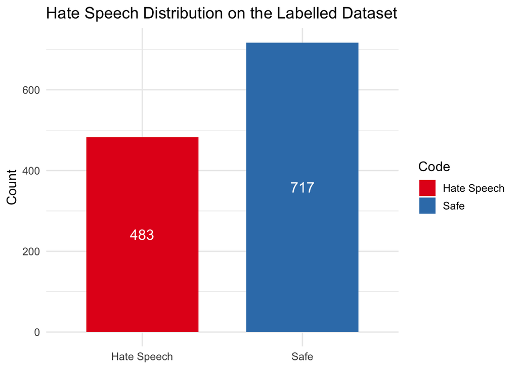

```r
labelled <- readxl::read_excel("/Users/PaulMUTAMBA/Downloads/Labelled_Posts.xlsx")

df_counts <- labelled %>%
  mutate(hate_speech = ifelse(hate_speech == "1", "Hate Speech", "Safe")) %>%
  count(hate_speech)

ggplot(df_counts, aes(x = hate_speech, y = n, fill = hate_speech)) +
  geom_col(width = 0.7) +
  geom_text(
    aes(y = n / 2, label = n),
    color = "white",
    size = 5
  ) +
  scale_fill_brewer(palette = "Set1") +
  labs(
    x = NULL,
    y = "Count",
    fill = "Code",
    title = "Hate Speech Distribution on the Labelled Dataset"
  ) +
  theme_minimal(base_size = 13)
```

The Labelled Dataset can be found in **Appendix B — Labelled Dataset.** The manually coded dataset exhibited a moderate class imbalance. Of the 1,200 annotated posts, 717 were labeled as non–hate speech (class 0) and 483 as hate speech (class 1). Although the distribution was not perfectly balanced, both categories were sufficiently represented to support a reliable estimation of intercoder agreement and to enable effective training and evaluation of the supervised classification models.

To ensure that this imbalance did not bias model performance, evaluation metrics that are robust to uneven class distributions, such as precision, recall, and F1-score, were prioritized over accuracy alone in subsequent analyses.

### Training Models

1. Naive Bayses
2. Logisitc Regression
3. Random Forest

We ran these models using different Preprocessing and feature representation.

**Preprocessing and Feature representation for ML (4 options)**

As there is no universal preprocessing pipeline, we intend to test a small set of slightly different options and later choose the optimal one through validation:

1. First option: **unigrams**. The most straightforward and basic option.
2. Second option: **unigrams + bigrams**. Additionally captures short phrases like “not N”, fixed expressions, certain slurs.
3. Third option: **Lemmatized unigrams.** Reduces each words to its roots.
4. Fourth option: **lemmatized unigrams + bigrams**. Captures short phrases and reduces sparsity by reducing each word to its root.

In this section, we focus our analysis on the preprocessing pipeline approach that achieved the best performance: **unigrams with lemmatization. Appendix A** presents the results for all preprocessing variants.

#### Naive Bayes

1. Data Set UP: To prepare the data, we transform the cleaned text field into a tokenized corpus. We then use the `createDataPartition` function to split this corpus into an 80% training set and a 20% testing set. Because `createDataPartition` specifically generates row indices, we can easily map the original labels to their corresponding documents in the corpus.
2. Cross Validation: Following the initial data split, we implement a 5-fold cross-validation process using the `createFolds` function to ensure the model generalizes well to unseen data. Within a loop that iterates through each fold, we partition the training tokens into a sub-training set and a validation set. We then generate a Document-Feature Matrix (DFM) for the training subset, by trimming rare terms to remove noise and prevent the model from learning from infrequent words.
3. Data Leakage: To maintain consistency and prevent data leakage, we use the `dfm_match` function to ensure the validation DFM utilizes the exact same features defined during the training phase.
4. Model Training: After preparing the matrices, we train a Naive Bayes model and generate predictions, carefully forcing the results into a factor format with consistent levels to ensure accurate evaluation. To train our model we use `textmodel_nb` from `quanteda.textmodels` which is more suitable for corpus. It does not requires to transform our DFM into a matrix.
5. Metrics: For each iteration, we calculate the accuracy, precision, recall, and F1-score. Finally, we average these metrics across all five folds to provide a robust and stable assessment of the model’s overall performance.

```r
cleaned <- read_csv('/Users/PaulMUTAMBA/Downloads/mensrights_text_variants_for_ml.csv')
data <- cleaned[labelled$X, , drop = FALSE]

data$label <- labelled$hate_speech

set.seed(1991)
split <- caret::createDataPartition(y= data$label, p = 0.8, list = FALSE) #split partition

fullcorpus <- quanteda::corpus(data, docid_field = "id",
                           text_field = "text_toks_lem")
full_tokens <- quanteda::tokens(fullcorpus, remove_punct = TRUE)
train_tokens <- full_tokens[split]
trainY       <- as.factor(data$label)[split]

set.seed(1991)

# Create Folds for cross validation
k <- 5
folds <- createFolds(trainY, k = k, list = TRUE)

# Initialize results storage
cv_results <- data.frame(
  Accuracy = numeric(k),
  Precision = numeric(k),
  Recall = numeric(k),
  F1 = numeric(k)
)

# 2. Cross-Validation Loop
for(i in 1:k) {
  test_idx <- folds[[i]]

  # A. Split tokens based on fold indices
  tk_train <- train_tokens[-test_idx]
  tk_test  <- train_tokens[test_idx]
  y_train  <- trainY[-test_idx]
  y_test   <- trainY[test_idx]

  # B. Process DFM (Train)
  # Trimming happens here to prevent data leakage from test set
  dfm_train <- dfm(tk_train) %>%
    dfm_trim(min_docfreq = 5, min_termfreq = 3, docfreq_type = "count") %>%
    dfm_weight(scheme = "boolean")

  # C. Process DFM (Test)
  # CRITICAL: Match features to training set (handles unseen/missing words)
  dfm_test <- dfm(tk_test) %>%
    dfm_match(features = featnames(dfm_train)) %>% # Trim to reduce matrix size
    dfm_weight(scheme = "boolean")

  # D. Train Bernoulli Naive Bayes
  nb_model <- textmodel_nb(dfm_train, y_train,distribution = "Bernoulli")

  # E. Predict
  raw_preds <- predict(nb_model, newdata = dfm_test)

  # FIX: Force predictions to be a factor with the exact same levels as training data.
  # This prevents confusionMatrix errors if a specific class is never predicted in a fold.
  preds <- factor(raw_preds, levels = levels(y_train))

  # F. Evaluate
  # (Removed the duplicate confusionMatrix call found in original code)
  cm <- confusionMatrix(preds, y_test, mode = "prec_recall", positive = "1")

  cv_results$Accuracy[i]  <- cm$overall["Accuracy"]
  cv_results$Precision[i] <- cm$byClass["Precision"]
  cv_results$Recall[i]    <- cm$byClass["Recall"]
  cv_results$F1[i]        <- cm$byClass["F1"]

}

# Output final mean metrics
print(colMeans(cv_results, na.rm = TRUE))
```

```
##  Accuracy Precision    Recall        F1
## 0.6458333 0.5739062 0.4389610 0.4964135
```

After several attempts, Bernoulli Naive Bayes achieved higher accuracy than Multinomial Naive Bayes. Bernoulli Naive Bayes considers only the presence or absence of a token in a document, whereas Multinomial Naive Bayes accounts for token frequencies, which in this case added noise rather than improving predictions.

The Bernoulli model achieved an overall mean **Accuracy of 64.6%** during cross-validation. In terms of identifying the positive class (Hate Speech), it reached a mean **Precision of 57.4%** and a mean **Recall of 43.9%**, resulting in an **F1-score of 0.496**. These metrics indicate that while the model is moderately effective at making correct predictions, it currently struggles to capture more than half of the actual hate speech instances within the dataset.

#### Logistic Regression

```r
train_tokens <- full_tokens[split]
test_tokens <- full_tokens[-split]

y_train <- as.factor(data$label)[split]
y_test  <- as.factor(data$label)[-split]

levels(y_train) <- make.names(levels(y_train))
levels(y_test)  <- make.names(levels(y_test))

set.seed(1991)

dfm_train <- dfm(train_tokens) %>%
  dfm_trim(min_docfreq = 5, min_termfreq = 3) %>% # Trim to reduce matrix size
  dfm_tfidf() #use tfidf

dfm_test <- dfm(test_tokens) %>%
  dfm_match(features = featnames(dfm_train)) %>%
  dfm_tfidf()

x_train_mat <- as.matrix(dfm_train) #Caret works with matrices of dfs, so we have transfom the dfms into matrices
x_test_mat  <- as.matrix(dfm_test)

ctrl <- trainControl(
  method = "cv",                # 5-Fold Cross Validation
  number = 5,
  sampling = "down",            # AUTOMATICALLY fixes class imbalance
  classProbs = TRUE,            # Needed for ROC/AUC
  summaryFunction = prSummary  # Optimizes for Precision/Recall/F1
)

lr_caret <- train(
  x = x_train_mat,
  y = y_train,
  method = "glmnet",
  metric = "F",                 # Optimize for F1 Score (requires prSummary)
  trControl = ctrl,
  tuneLength = 5
)

preds <- predict(lr_caret, newdata = x_test_mat)
confusionMatrix(preds, y_test, mode = "prec_recall", positive = "X1")
```

```
## Confusion Matrix and Statistics
##
##           Reference
## Prediction  X0  X1
##         X0 119  58
##         X1  23  40
##
##                Accuracy : 0.6625
##                  95% CI : (0.5989, 0.7221)
##     No Information Rate : 0.5917
##     P-Value [Acc > NIR] : 0.0144426
##
##                   Kappa : 0.2606
##
##  Mcnemar's Test P-Value : 0.0001582
##
##               Precision : 0.6349
##                  Recall : 0.4082
##                      F1 : 0.4969
##              Prevalence : 0.4083
##          Detection Rate : 0.1667
##    Detection Prevalence : 0.2625
##       Balanced Accuracy : 0.6231
##
##        'Positive' Class : X1
##
```

The Logistic Regression model produced an overall **Accuracy of 66.3%**. For the positive class (Hate Speech), the model demonstrated a **Precision of 63.5%** and a **Recall of 40.8%**, yielding an **F1-score of 0.497**. While the precision shows a slight improvement over the Naive Bayes approach, the low recall suggests the model still misses a substantial portion of hate speech content, and the **Kappa of 0.261** indicates only fair agreement beyond what would be expected by chance.

#### Random Forest

We did not use the random forest implementation from the `caret` library because it does not allow direct control over the number of trees, and with our sparse, high dimensional dataset the training time became prohibitive. Instead, we relied on the `randomForest` package. This implementation does not perform explicit cross validation; rather, it uses the out of bag (OOB) error for model evaluation. OOB error acts as a proxy for cross validation because each tree is trained on a bootstrap sample, leaving out roughly one third of the observations, which are then used to evaluate the model. This repeated internal validation provides an unbiased estimate of generalization performance.

The document feature matrices were converted into data frames, the class label was appended to the training data, and all feature names were standardized to valid R identifiers. A random forest classifier with 70 trees was then trained. Feature name consistency was enforced for the test set.

```r
set.seed(1991)
split <- caret::createDataPartition(y= data$label, p = 0.8, list = FALSE)
corpus <- quanteda::corpus(data, docid_field = "id",
       text_field = "text_toks_lem") %>%  quanteda::tokens(remove_punct=T) %>% dfm() %>% dfm_trim(min_docfreq = 5, min_termfreq = 3, docfreq_type = "count") %>% dfm_tfidf()

train.data <- corpus %>% dfm_subset(rownames(corpus) %in% rownames(corpus)[split])
test.data <- corpus %>% dfm_subset(!rownames(corpus) %in% rownames(corpus)[split])

response <- factor(data$label, levels = c("1", "0"))
trainY <- response[split]
testY <- response[-split]
trainY <- as.factor(data$label)[split]

set.seed(1991)
levels(trainY) <- make.names(levels(trainY))
levels(testY)  <- make.names(levels(testY))

Xtrain.df <- as.data.frame(as.matrix(train.data))
Xtest.df <- as.data.frame(as.matrix(test.data))

Xtrain.df$label <- trainY
colnames(Xtrain.df) <- make.names(colnames(Xtrain.df))
RFmodel <- randomForest::randomForest(label ~ ., data=Xtrain.df, ntree = 70)
colnames(Xtest.df) <- make.names(colnames(Xtest.df))
predRF <- predict(RFmodel, Xtest.df)
print(RFmodel)
```

```
##
## Call:
##  randomForest(formula = label ~ ., data = Xtrain.df, ntree = 70)
##                Type of random forest: classification
##                      Number of trees: 70
## No. of variables tried at each split: 52
##
##         OOB estimate of  error rate: 36.15%
## Confusion matrix:
##     X0  X1 class.error
## X0 438 137   0.2382609
## X1 210 175   0.5454545
```

```r
cm.po3 <- confusionMatrix(data = predRF, reference = testY, positive= "X1", mode = "prec_recall")
cm.po3
```

```
## Confusion Matrix and Statistics
##
##           Reference
## Prediction  X1  X0
##         X1  53  23
##         X0  45 119
##
##                Accuracy : 0.7167
##                  95% CI : (0.6551, 0.7728)
##     No Information Rate : 0.5917
##     P-Value [Acc > NIR] : 3.841e-05
##
##                   Kappa : 0.3925
##
##  Mcnemar's Test P-Value : 0.01088
##
##               Precision : 0.6974
##                  Recall : 0.5408
##                      F1 : 0.6092
##              Prevalence : 0.4083
##          Detection Rate : 0.2208
##    Detection Prevalence : 0.3167
##       Balanced Accuracy : 0.6894
##
##        'Positive' Class : X1
##
```

The Random Forest model significantly improved performance, achieving an **Accuracy of 71.7%**, which is well above the No Information Rate ($p < 0.001$). Regarding the identification of hate speech, the model reached a **Precision of 69.7%** and a **Recall of 54.1%**, resulting in a much stronger **F1-score of 0.609**. The Out-of-Bag (OOB) error rate of 36.15% indicates moderate generalization performance, close to the **Kappa of 0.393** suggests a moderate level of agreement, indicating that this ensemble approach is more effective at balancing detection and correctness than the previous models.

The table below summarizes the performance metrics for the Bernoulli Naive Bayes, Logistic Regression, and Random Forest models based on the cross-validation and test results.

| **Model** | **Accuracy** | **Precision** | **Recall** | **F1-Score** |
| --- | --- | --- | --- | --- |
| **Bernoulli Naive Bayes** | 64.6% | 57.4% | 43.9% | 0.496 |
| **Logistic Regression** | 66.3% | 63.5% | 40.8% | 0.497 |
| **Random Forest** | **71.7%** | **69.7%** | **54.1%** | **0.609** |

Comparing the three approaches, the Random Forest model is clearly the top performer across every metric. It provides the highest Accuracy and F1-Score, showing a particularly significant jump in Recall compared to the other two. While the Logistic Regression model offered a slight improvement in Precision over Naive Bayes, it struggled the most with Recall, missing nearly 60% of hate speech instances.

### Analyse of predictors

To understand which terms most strongly influenced the detection of hate speech toward women, we examined variable importance using the Mean Decrease in Gini index on our best model — Random Forest. This metric indicates how much each predictor contributes to reducing classification uncertainty across the forest.

```r
randomForest::importance(RFmodel)%>% data.frame() %>% top_n(20, MeanDecreaseGini) %>% arrange(desc(MeanDecreaseGini))
```

```
##           MeanDecreaseGini
## woman            10.940085
## man               6.715495
## feminist          6.079088
## rapist            2.487397
## gender            2.083590
## get               1.939315
## reverse           1.904620
## male              1.892107
## fuck              1.820379
## feminism          1.796024
## privilege         1.661072
## time              1.585199
## not               1.572908
## can               1.511135
## make              1.500788
## say               1.430640
## right             1.405415
## think             1.395905
## believe           1.338461
## female            1.334713
```

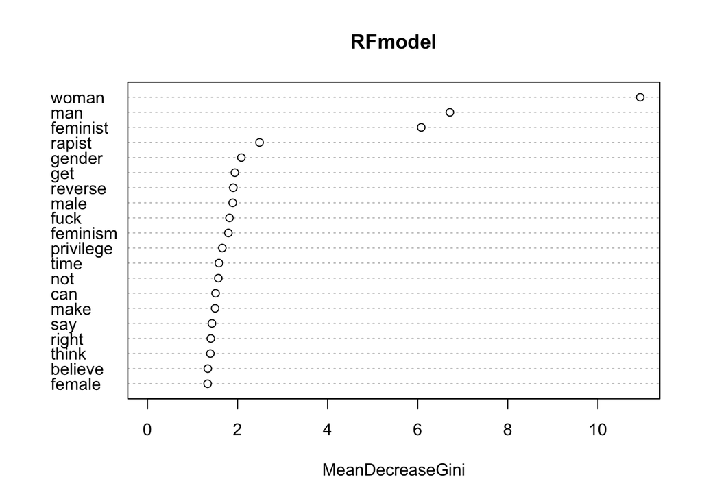

```r
randomForest::varImpPlot(RFmodel, n.var = 20)
```

The most important predictors are explicitly gendered terms, with *woman* and *man* showing the highest importance. This suggests that direct references to women and gender comparisons are central cues for identifying misogynistic content. Ideologically loaded terms such as *feminist*, *feminism*, and *gender* also rank highly, reflecting that hate speech toward women often emerges within debates or attacks related to feminism and gender politics. The presence of highly offensive terms like *rapist* and *fuck* further indicates that explicit and aggressive language is a strong signal of hateful or abusive expressions targeting women. Additional terms such as *male*, *reverse*, and *get* contribute more moderately, likely capturing contextual patterns in narratives that frame women in opposition to men or invoke claims of “reverse” discrimination or what we coded as Men grievance.

Overall, the importance analysis shows that the model relies primarily on gender specific and derogatory vocabulary, which aligns well with the task of predicting hate speech directed at women rather than general negativity or neutral discourse.

#### False Positive Posts

Next, let’s analyse the wrongly predicted tweets and learn from their characteristics. The False Positive Posts are those one in the test data that our model predicts as hate speech while we coded them as being safe.

```r
false_positive_indices <- which(predRF == "X1" & testY != "X1")
false_positive_indices <- as.numeric(false_positive_indices)
false_positive_posts <- labelled %>%  filter(X %in% as.numeric(rownames(Xtest.df[false_positive_indices, , drop = FALSE]))) %>% select(title, selftext, hate_speech, X)

head(false_positive_posts$selftext, 5)
```

```
## [1] "I'd appreciate you reading through this, and not just downvoting. I am a feminist, and a man, dating and living with a feminist who is not a man. I care about equality. But I have seen some of you getting worked up about feminists acting like all men are rapists. I've decided to try an expla…
## [2] "So here's what happened, when I was choosing my classes a few months ago they didn't have space in the one I wanted, so instead I chose this one called \"Gender, society and rights\" because I thought it sounded cool (should've thought about it more), first day of class I'm met with a teache…
## [3] "I've heard some people call AMC's Mad men feminist propaganda, but I've found that it often portrays male and female characters and their relationships honestly enough.\r\n \r\n Don Draper has his flaws but is a good man. His wife Betty is a fickle, petulant child.\r\n \r\n Still, it may be …
## [4] "I'm a fervent supporter of abortion. If you think it's morally wrong I can accept that, but I can't accept you imposing your morality on another.\r\n \r\n That said it strikes me as a gross injustice that a man has no rights whatsoever regarding his right to choose to be a parent.\r\n \r\n E…
## [5] "When I found this subreddit I was very happy to know that it existed as I have long been an advocate for male advocacy. After reading through it for the past few weeks I've become increasingly concerned that this movement may be heading in the wrong direction. I think that this community is …
```

The five false positives share a common feature: they contain contentious gender-related discourse and critical language about feminism or gender politics, but do not meet the threshold for hate speech. **Patterns:**

**1. Critical but non-hostile discourse**

Several posts (e.g., FP1, FP4, FP5) adopt a critical stance toward feminism, gender norms, or reproductive rights, yet they do so in a reflective, argumentative, or conciliatory tone rather than a hateful one.

The model appears to have over-relied on ideological keywords (e.g., feminists, patriarchy, sexism, rights, men) as signals of hate speech, even when these terms were used in non-hostile or conciliatory contexts.

**2. Presence of Gender Stereotypes Without Explicit Abuse**

FP3 contains negative character judgments (e.g., describing a female character as “a fickle, petulant child”), which may resemble misogynistic language but is framed as media criticism, not as an attack on women as a group.

**3. Sensitive Topics Triggering Over-Detection**

FP4 discusses abortion and reproductive rights, which are topics often associated with polarized discourse. Although the post explicitly condemns sexist language, the surrounding semantic field likely increased the model’s tendency to predict hate speech.

These errors suggest that the classifier tends to fail on the side of over-inclusion, flagging posts that discuss gender conflict even when they aim for dialogue, critique, or moderation. This pattern is consistent with the study’s deliberate prioritization of high recall, but it also highlights the difficulty of distinguishing ideological disagreement from hateful expression in politically charged contexts. For example, in FP#1, we can clearly detect that these patterns emerge and the systematic error takes place.

#### False Negative Posts

Next, we analyse the False Negative Posts. Those ones are predicted as Safe by the model while we coded them as being Hate speech.

```r
false_negative_indices <- which(predRF == "X0" & testY != "X0")
false_negative_posts <- labelled %>%  filter(X %in% as.numeric(rownames(Xtest.df[false_negative_indices, , drop = FALSE]))) %>% select(title, selftext, hate_speech, X)

head(false_negative_posts$selftext, 5)
```

```
## [1] "All that really says is that women like spending other people's money.\r\n \r\n whether it be her husbands money or money taken from men by gun point by the government. I heard somewhere that women receive more money than they pay in taxes."
## [2] "I am active in the menslib community in the SF bay area. MKP, and a few other groups are important passions of mine. Menslib doesn‚Äôt want to hear from men who disagree with their dogma. I pointed out the wage gap study of nurses. Male nurses make several percent more on average. They do it…
## [3] "So, I decided to come to MRA for help. My good friend, who is a wonderful man and awesome father to his son, is in the middle of an ugly divorce. His eventual ex is doing everything in her power to try and convince him to come back to her. She abused him, emotionally and physically, threaten…
## [4] "I know that something like 95% of workplace accidental deaths are men. If we remove those numbers, and the amount of men (and fewer women) that die young in war, is there a major effect on life expectancy, or is it negligible?\r\n \r\n What I'm saying is, do women live longer purely because …
## [5] "So is anyone going to say anything about how all men around their 18th birthday have to register in case the draft needs to be returned. Women don't sign up for this thing. Is there a reasoning that they haven't changed this?\r\n \r\n \r\n This could go both as discrimination against men or …
```

The false negatives, by contrast, reveal how the model sometimes fails to detect hate speech when it is expressed in subtle, indirect, or normalized forms. A qualitative review of the five false negative cases reveals that not all errors can be attributed solely to model failure. Instead, these examples highlight the inherent ambiguity of hate-speech annotation, particularly when misogyny is expressed in indirect, coded, or normalized ways.

Several of the false negatives rely on implicit stereotypes and grievance-based narratives rather than overt insults or threats. For instance, statements portraying women as financially exploitative (FN1) or framing feminist spaces as ideologically hostile to men (FN2), communicate antagonism through implication rather than explicit abuse.

This finding points out a key methodological insight: errors in automated hate-speech detection do not always indicate clear misclassification, but may instead reveal the contested and context-dependent nature of the category itself. Recognizing this ambiguity strengthens the interpretation of model performance by situating it within the broader epistemic limits of both computational and human judgment.

### Model Tuning

Based on the results above, the next step is to improve the predictive power of our model by increasing recall. As mentioned earlier, our priority is to minimize the number of Hate Speech posts that are not flagged by the model.

```r
p_yes <- predict(RFmodel, newdata = Xtest.df, type = "prob")[, "X1"]

my_roc_curve <- roc(response = testY, predictor = p_yes, levels = c("X1","X0"))
my_roc_curve
```

```
##
## Call:
## roc.default(response = testY, predictor = p_yes, levels = c("X1",     "X0"))
##
## Data: p_yes in 98 controls (testY X1) > 142 cases (testY X0).
## Area under the curve: 0.7552
```

```r
#plot(my_roc_curve)

optimal_th = my_roc_curve$threshold[which.max(my_roc_curve$sensitivities + my_roc_curve$specificities)]
optimal_th
```

```
## [1] 0.3928571
```

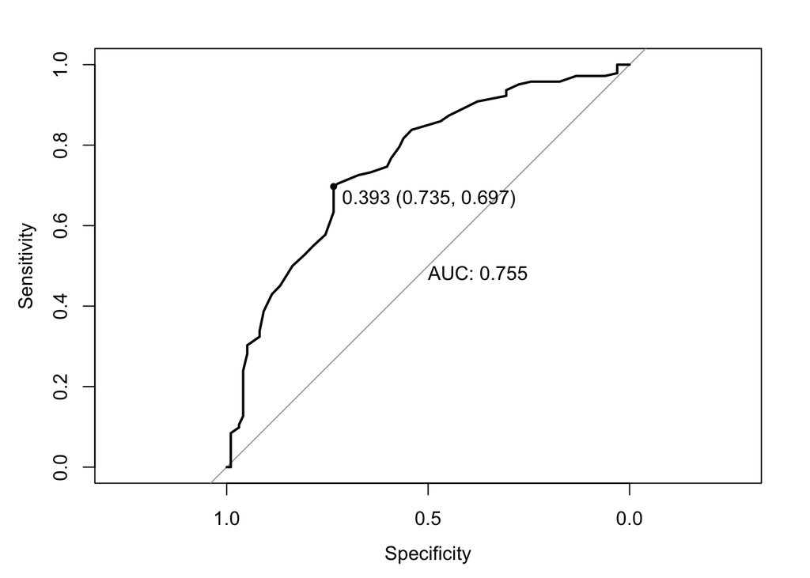

```r
roc_2 = roc(testY ~ p_yes, plot=T, print.auc=T,
            print.thres="best", print.thres.patterns="Best threshold: %1.2f")
```

```r
pred_optimal = as.factor(ifelse(p_yes>optimal_th , "X1", "X0"))

confusionMatrix(data = pred_optimal, reference = testY, positive= "X1", mode = "prec_recall")
```

```
## Confusion Matrix and Statistics
##
##           Reference
## Prediction X1 X0
##         X1 72 43
##         X0 26 99
##
##                Accuracy : 0.7125
##                  95% CI : (0.6508, 0.7689)
##     No Information Rate : 0.5917
##     P-Value [Acc > NIR] : 6.775e-05
##
##                   Kappa : 0.4206
##
##  Mcnemar's Test P-Value : 0.05408
##
##               Precision : 0.6261
##                  Recall : 0.7347
##                      F1 : 0.6761
##              Prevalence : 0.4083
##          Detection Rate : 0.3000
##    Detection Prevalence : 0.4792
##       Balanced Accuracy : 0.7159
##
##        'Positive' Class : X1
##
```

```r
confmat_opt = table(testY, pred_optimal)
```

Applying this optimized threshold resulted in a more balanced performance profile. While the overall **Accuracy remained stable at 71.3%**, we observed a substantial improvement in the model’s ability to identify hate speech, with **Recall rising to 73.5%**. This shift led to a significantly higher **F1-score of 0.676** and a **Kappa of 0.421**, indicating moderate-to-substantial agreement. Although Precision dipped slightly to 62.6% as a trade-off for capturing more positive cases, the optimized model is now far more effective at catching instances of hate speech that the default settings previously missed.

All in all, The **Random Forest model** emerged as the superior solution, demonstrating a naturally higher capacity to handle the complex, non-linear relationships found in text data. A notable limitation of in our model training is the inability to perform an exhaustive **hyperparameter grid search** (tuning parameters such as `mtry`, `nodesize`, or the number of trees). Due to significant **computational power limits**, the optimization was primarily focused on **threshold tuning** rather than a full search across the model’s configuration space. While the threshold adjustment provided substantial gains in recall, further fine-tuning of the Random Forest’s internal structure could potentially reduce the current Out-of-Bag (OOB) error rate and further sharpen precision.

### Hate Speech Detection

Given that the tuning model offers good predictive power, we propose implementing it to detect hate speech on the rest of the subreddit’s posts, i.e. 43,135 posts.

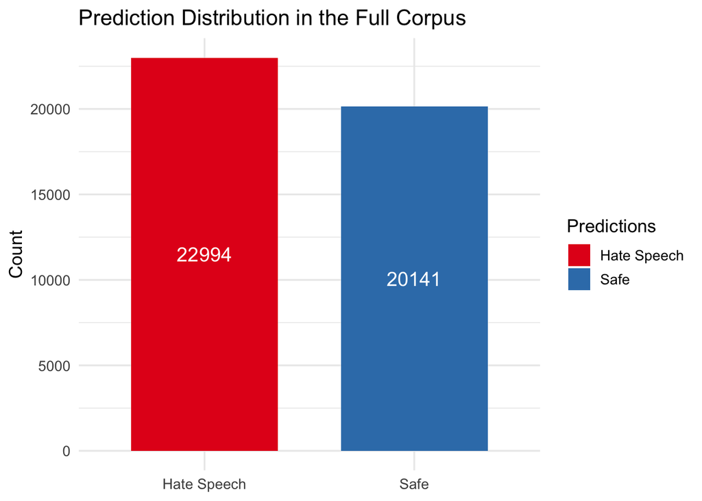

```r
full <- cleaned[-labelled$X, , drop = FALSE]

fullcorpus <- quanteda::corpus(full, docid_field = "id",
                           text_field = "text_toks_lem") %>%  quanteda::tokens(remove_punct=T) %>% dfm() %>% dfm_trim(min_docfreq = 5, min_termfreq = 3, docfreq_type = "count") %>% dfm_tfidf()
fulltfidf.df <- as.data.frame(as.matrix(fullcorpus))
colnames(fulltfidf.df) <- make.names(colnames(fulltfidf.df))

prediction_full <- predict(RFmodel, newdata = fulltfidf.df, type = "prob")[, "X1"]

pred_fac <- factor(ifelse(prediction_full > optimal_th, "X1","X0"), levels=c("X1","X0"))

full$prediction <- pred_fac

df_counts <- full %>%
  mutate(prediction = ifelse(prediction == "X1", "Hate Speech", "Safe")) %>%
  count(prediction)

ggplot(df_counts, aes(x = prediction, y = n, fill = prediction)) +
  geom_col(width = 0.7) +
  geom_text(
    aes(y = n / 2, label = n),
    color = "white",
    size = 5
  ) +
  scale_fill_brewer(palette = "Set1") +
  labs(
    x = NULL,
    y = "Count",
    fill = "Predictions",
    title = "Prediction Distribution in the Full Corpus"
  ) +
  theme_minimal(base_size = 13)
```

On the 43135 posts, 22994 (53%) are predicted as containing hate speech targeting women, and 20141 (47%) are predicted as being safe.

Next we analyse how hate speech varied trhoughout the years in the subreddit.

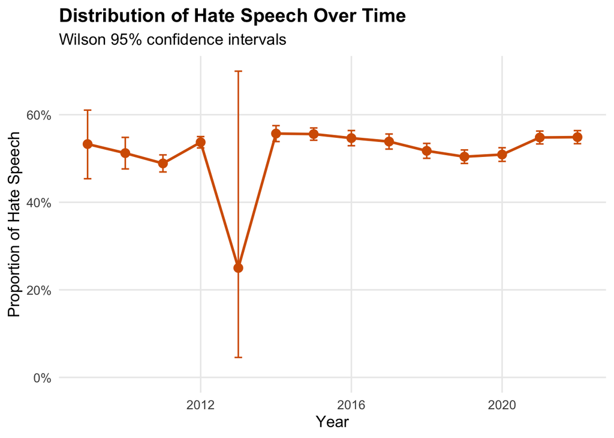

```r
yearly_dist <- full %>%
  mutate(
    hate = ifelse(prediction == "X1", 1, 0)
  ) %>%
  group_by(year) %>%
  summarise(
    n = n(),
    hate_count = sum(hate),
    prop_hate = hate_count / n
  )


#install.packages("binom")
library(binom)
ci <- binom.confint(
  x = yearly_dist$hate_count,
  n = yearly_dist$n,
  methods = "wilson"
)

yearly_dist <- yearly_dist %>%
  mutate(
    lower = ci$lower,
    upper = ci$upper
  )


ggplot(yearly_dist, aes(x = year, y = prop_hate)) +
  geom_point(size = 3, color = "#D55E00") +
  geom_line(color = "#D55E00", linewidth = 1) +
  geom_errorbar(
    aes(ymin = lower, ymax = upper),
    width = 0.2,
    color = "#D55E00"
  ) +
  scale_y_continuous(
    labels = scales::percent_format(accuracy = 1),
    limits = c(0, NA)
  ) +
  labs(
    x = "Year",
    y = "Proportion of Hate Speech",
    title = "Distribution of Hate Speech Over Time",
    subtitle = "Wilson 95% confidence intervals"
  ) +
  theme_minimal(base_size = 13) +
  theme(
    plot.title = element_text(face = "bold"),
    panel.grid.minor = element_blank()
  )
```

The figure above presents the yearly proportion of hate speech in the corpus, together with 95% Wilson confidence intervals. Overall, the prevalence of hate speech remains relatively stable over time, fluctuating around 50–55% in most years.

A notable deviation occurs in 2013, where the estimated proportion of hate speech drops sharply and is accompanied by a substantially wider confidence interval. This pattern reflects the closure of the subreddit during that year, which resulted in a markedly reduced number of observations. Consequently, the estimate for 2013 is subject to considerable statistical uncertainty and should not be interpreted as a substantive change in hate speech prevalence.

Excluding this structurally constrained year, the temporal trend suggests moderate year-to-year variation but no evidence of a sustained increase or decrease in hate speech over the observed period.

#### Predictions Validation

To validate the predictions, we randomly select 300 posts and code them manually to see whether the model perform accurately on unseen data.

```r
sample_validation <- read_csv('/Users/PaulMUTAMBA/Downloads/Validation_set - Sheet1.csv')


sample_validation$prediction <-  ifelse(sample_validation$prediction == "X1", "Hate Speech", "Safe")

sample_validation$prediction <- tolower(sample_validation$prediction)
sample_validation$analysis_result <- tolower(sample_validation$analysis_result)
#table(sample_validation$prediction)
#table(sample_validation$analysis_result)
sample_validation$prediction <- as.factor(sample_validation$prediction)
sample_validation$analysis_result <- as.factor(sample_validation$analysis_result)
cm.vald <- confusionMatrix(data = sample_validation$analysis_result , reference = sample_validation$prediction, positive= "hate speech", mode = "prec_recall")

cm.vald
```

```
## Confusion Matrix and Statistics
##
##              Reference
## Prediction    hate speech safe
##   hate speech         103   24
##   safe                 65  108
##
##                Accuracy : 0.7033
##                  95% CI : (0.6481, 0.7545)
##     No Information Rate : 0.56
##     P-Value [Acc > NIR] : 2.387e-07
##
##                   Kappa : 0.4174
##
##  Mcnemar's Test P-Value : 2.235e-05
##
##               Precision : 0.8110
##                  Recall : 0.6131
##                      F1 : 0.6983
##              Prevalence : 0.5600
##          Detection Rate : 0.3433
##    Detection Prevalence : 0.4233
##       Balanced Accuracy : 0.7156
##
##        'Positive' Class : hate speech
##
```

Recall was prioritized in model evaluation because the central aim of the study was to analyze the thematic composition of hate-speech discourse rather than to optimize classification accuracy per se. Missing hate-speech posts at the detection stage would have permanently excluded relevant material from the topic-modeling analysis, risking an incomplete or biased representation of dominant narratives. In contrast, allowing some non–hate-speech posts into the hate-speech subset was considered less problematic, as topic modeling is relatively robust to limited noise. Emphasizing recall, therefore, ensured broad coverage of hate-speech content while safeguarding the validity of the subsequent thematic analysis

## Topic Modelling

To explore the thematic structure of hate speech in r/MensRights, we applied topic modeling to identify dominant patterns of discussion. Guided by the hypothesis that these patterns are shaped by orthodox men’s rights narratives (Ging, 2019), we aimed to uncover topics related to domestic violence against men, child custody and divorce, and the feminisation of education. This approach allows us to systematically analyze the content of the subreddit and link observed themes to established discourses in the manosphere.

### Coherence and Exclusivity

To examine the thematic structure of hate speech in r/MensRights, we employ **Latent Dirichlet Allocation (LDA)**, a widely used topic modeling technique that identifies clusters of words representing distinct themes. The LDA as K—the number of topics as hyperparameter. To determine the most suitable number of topics for our corpus, we evaluate models across a range of K values using topic **coherence**, which measures the semantic similarity of words within a topic, and **exclusivity**, which assesses how distinct each topic is from the others. This approach allows us to select a model that captures meaningful and well-separated themes.

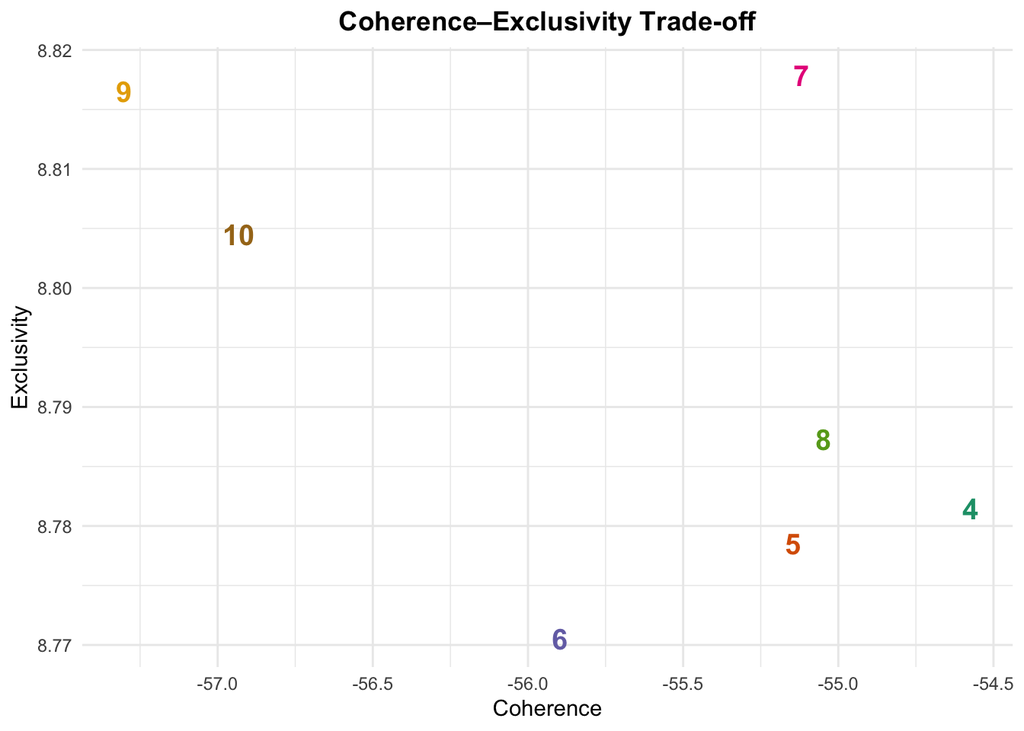

```r
hate_df <- full %>%
  filter(prediction == "X1") %>%
  select(text_toks_lem)

corp_hate <- corpus(hate_df, text_field = "text_toks_lem")

dfm_hate <- corp_hate %>%
  quanteda::tokens(remove_punct = TRUE) %>%
  dfm() %>%
  dfm_remove(stopwords("english")) %>%
  dfm_trim(
    min_docfreq = 0.02,
    max_docfreq = 0.7,
    docfreq_type = "prop"
  )

# ------- Keeping top 600 features to further reduce sparsity ------
top_features <- names(topfeatures(dfm_hate, n = 600))
dfm_hate <- dfm_hate[, top_features]

# cat("Documents:", nrow(dfm_hate), "\n")
# cat("Features:", nfeat(dfm_hate), "\n")
# cat("Sparsity:", sparsity(dfm_hate), "\n")

set.seed(123)
sample_docs <- sample(docnames(dfm_hate), 5000)
dfm_sample <- dfm_hate[sample_docs, ]

dtm_sample <- convert(dfm_sample, to = "topicmodels")

calculate_perplexity <- function(k, dtm) {
  lda_model <- LDA(dtm, k = k, control = list(seed = 123))
  perplexity(lda_model)
}

k_vals <- seq(4, 10, by = 1)
perplexities <- sapply(k_vals, calculate_perplexity, dtm = dtm_sample)

perplexity_df <- data.frame(
  k = k_vals,
  perplexity = perplexities
)


# ggplot(perplexity_df, aes(x = k, y = perplexity)) +
#   geom_line() +
#   geom_point() +
#   labs(
#     title = "Perplexity vs Number of Topics",
#     x = "Number of Topics",
#     y = "Perplexity"
#   ) +
#   theme_classic()

multi_lda <- function(k, dtm){
  LDA(dtm, k = k, control = list(seed = 123))
}

lda_models <- lapply(k_vals, multi_lda, dtm_sample)
names(lda_models) <- k_vals

diag_list <- lapply(lda_models, topic_diagnostics, dfm_sample, 10)
diag_df <- bind_rows(diag_list, .id = "K") %>% mutate(K = as.numeric(K))

diag_summary <- diag_df %>%
  group_by(K) %>%
  summarise(
    coherence = mean(topic_coherence),
    exclusivity = mean(topic_exclusivity)
  )

#diag_summary

## Plot Coherence–Exclusivity Trade-off
ggplot(diag_summary, aes(coherence, exclusivity)) +
  geom_text(aes(label = K, color = factor(K)), size = 5, fontface = "bold") +
  scale_color_brewer(palette = "Dark2") +
  labs(
    x = "Coherence",
    y = "Exclusivity",
    title = "Coherence–Exclusivity Trade-off"
  ) +
  theme_minimal() +
  theme(
    plot.title = element_text(face = "bold", hjust = 0.5),
    legend.position = "none"
  )
```

Therefore we ran a LDA model with K = 8.

### LDA

Since we have an extremely large corpus, we decided to use the `MalletLDA` function for topic modeling since it is highly efficient and can handle large text corpora faster. The MalletLDA runs a LDA model by using JAVA in the background — a programming language that is optmized to work on large matrices unlike R.

```r
posthatespeech <- full %>% select("id","text_raw", "text_tok", "year", "prediction") %>% filter(prediction == "X1")

mallet.instances <- mallet.import(id.array=as.character(posthatespeech$id),
                                  text.array=posthatespeech$text_tok)
topic.model <- MalletLDA(num.topics=8) # number of topics

# fixing seed for reproducibility
topic.model$setRandomSeed(396L)
topic.model$loadDocuments(mallet.instances)
topic.model$setAlphaOptimization(30, 70) #optimization for MALLET (computational ressources used by the function to run faster the LDA)
vocabulary <- topic.model$getVocabulary() # corpus dictionary
word.freqs <- mallet.word.freqs(topic.model) # frequency table
## top frequent words (by doc frequency)
#word.freqs %>% arrange(desc(doc.freq)) %>% head(10)
topic.model$train(20)
topic.model$maximize(5)

doc.topics <- mallet.doc.topics(topic.model, smoothed=TRUE, normalized=TRUE)

topic.words <- mallet.topic.words(topic.model, smoothed=TRUE, normalized=TRUE)

topic.labels <- mallet.topic.labels(topic.model, topic.words, 10)
topic.labels
```

```
## [1] "women men male female less likely males work years many"
## [2] "child s children support not family pay father law money"
## [3] "men women not rape man woman sexual sex can people"
## [4] "violence gender boys social victims male s domestic girls abuse"
## [5] "not just like get one no time even know said"
## [6] "men women not s feminism feminist feminists rights people can"
## [7] "man woman young said boy sex time one now body"
## [8] "new show media public video including university act justice article"
```

Above are the topic labels for the eight themes of discussion in Mens’reddit posts flagged as hate speech.

#### **Topic Interpretation**

Based solely on the topic labels listed above — the words that characterize each theme — we can’t provide a meaningful interpretation for each of the eight discussion topics. Therefore, we had to reviewed the top posts associated with each topic and, using both the labels and the content of these posts, to derive an interpretation for each theme.

**Top post for topic 1**

```r
top.docs <- function(doc.topics, topic, docs, top.n=10) {
    head(docs[order(-doc.topics[,topic])], top.n)
}
top.docs(doc.topics, 1, posthatespeech$text_raw, 3)
```

```
## [1] "In many countries around the world, the state retirement age is higher for men; as a result, men often enjoy only half the years in retirement women do. One of the major male discriminations around the world is the issue of higher pension ages- in many countries, the state pension age where …
## [2] "In many countries around the world, the state retirement age is higher for men; as a result, men often only live to see half the years of retirement women do. One of the major male discriminations around the world is the issue of higher pension ages- in many countries, the state pension age …
## [3] "In many countries around the world, the state retirement age is higher for men; as a result, men often enjoy only half the years in retirement women do. Btw this is an article from [menarehuman](https://menarehuman.com/retirement-age/), a website a few of us run here. One of the major male d…
```

**Top posts for topic 2**

```r
top.docs(doc.topics, 2, posthatespeech$text_raw, 2)
```

```
## [1] "Legal Paternal Surrender This is going to be a long post, but I think I've developed a good explanation for why legal parental surrender should be allowed: All reasonable arguments against legal parental surrender rest on the idea that it would violate either a woman's right to bodily autono…
## [2] "Legal Abortion : Her Body, Her Choice, Her Responsibility I believe the topic of legal abortion for men is more than just about men's rights. I think it goes deeper. Fundamentally, you cannot hold a person responsible for something that they have no right to. A man has no right to a woman's …
```

**Top posts for topic 3**

```r
top.docs(doc.topics, 3, posthatespeech$text_raw, 2)
```

```
## [1] "Women and consent This is just gonna be a short rant I find it annoying how a lot of the time women just put themselves onto men and start touching them and trying to have sex, assuming the man likes it and often times the man does. I hate how they don’t have to ask for consent and they get …
## [2] "Will women recognize their privilege and power when it comes to dating. Women have all the privilege and power when it comes to dating, sex, relationships, reproduction. Men don’t have any power when it comes to those things. Getting relationships and sex is 100x easier for women then men an…
```

We applied this process to the eight discussion themes in our dataset. Below are the reports for each theme, based on their keywords and the posts which better represent each them.

**Topic 1: Gendered inequalities in retirement age and pension outcomes —** Pension Disparity

The first topic is primarily concerned with perceived structural discrimination against men in pension and retirement systems, framed through cross national comparisons between men and women. The most salient words women men male female less likely work years many indicate a strong gender comparative logic, with emphasis on differences in life expectancy, statutory retirement age, and years spent in retirement.

The exemplar texts show that discussion within this topic centres on the claim that men are systematically disadvantaged by higher statutory retirement ages despite having shorter life expectancies. Contributors frequently argue that this results in men enjoying significantly fewer years of retirement than women, often quantified through detailed country level statistics. These numerical comparisons are used rhetorically to frame the issue as a form of institutional or state sanctioned gender discrimination against men, particularly in countries that are otherwise portrayed as gender equal or feminist.

More broadly, this topic reflects a recurring men’s rights narrative in which gender equality policies are interpreted as privileging women while neglecting or obscuring disadvantages faced by men. The tone of the discussion positions male disadvantage as socially ignored or politically illegitimate, especially when contrasted with how similar inequalities would allegedly be treated if they affected women. Overall, Topic 1 captures debates around gender, work, longevity, and welfare policy, framed through claims of unequal treatment and injustice toward men in retirement and pension systems.

**Topic 2: Child support, paternal responsibility, and legal parental surrender —** Parental Rights & Support

Topic 2 centres on debates about fatherhood, child support obligations, and reproductive responsibility, with a strong focus on the legal and financial dimensions of parenting. The most salient terms child children support not family pay father law money indicate that this topic is structured around financial responsibility for children, particularly the obligation of fathers to provide child support within existing legal frameworks.

The representative texts reveal that discussions in this topic are dominated by arguments in favour of “legal parental surrender” or “financial abortion” for men. Contributors contend that because men lack bodily autonomy over pregnancy decisions, they should similarly have the right to opt out of legal and financial responsibility for a child within the same temporal window in which abortion is legally permitted. Child support is framed not primarily as a child’s right, but as an unfair legal burden imposed on men, especially when the decision to continue a pregnancy is presented as solely the woman’s choice.

In general, this topic reflects a recurring men’s rights discourse on reproductive asymmetry, where abortion law and child support legislation are interpreted as structurally privileging women while constraining men. The discussion often reframes fatherhood as a consensual contractual responsibility, arguing that legal and moral obligations should only arise when both parents explicitly choose parenthood. Overall, Topic 2 captures narratives that challenge existing family law by contesting norms of paternal responsibility, emphasizing financial autonomy, and redefining parental obligations in terms of individual choice rather than the welfare of the child.

**Topic 3: Sexual consent, rape, and perceived gendered power asymmetries —** Consent & Power Dynamics

Topic 3 focuses on discussions of sexual interactions, consent, and rape, framed through claims of gendered double standards between men and women. The most salient terms men women rape sexual sex man woman people indicate that this topic is centrally concerned with who is recognized as a legitimate victim or agent in sexual contexts, and how norms of consent are unevenly applied.

The example texts show that contributors frequently argue that men’s experiences of sexual coercion or unwanted sexual contact are minimized or dismissed, particularly when women are the initiators. Posts emphasize that women are allegedly not held accountable for violating men’s consent and that cultural expectations portray men as always desiring sex, thereby obscuring male vulnerability. This framing challenges dominant public narratives around sexual violence by asserting that men’s consent is routinely ignored and that female sexual misconduct is socially tolerated.

In parallel, the topic also incorporates broader claims about female privilege in dating and sexual markets. Discussions portray women as holding disproportionate power over sex, relationships, and reproduction, while men are depicted as structurally disadvantaged and lacking agency. These arguments often blend grievances about consent and rape with frustrations about dating inequality, reinforcing a narrative in which sexual norms and social attitudes systematically favour women.

Overall, Topic 3 captures a cluster of discourse that reframes sexual consent and rape through a men’s rights lens, emphasizing perceived double standards, underrecognition of male victimhood, and gendered power imbalances in sexual and romantic relationships.

**Topic 4: Gendered violence and male victimization —** Male Victimization

Topic 4 captures a men’s rights discourse that seeks to reframe violence as a gender inclusive issue, emphasizing underrecognition of abuse against men and boys and advocating for equal visibility, resources, and policy responses.

**Topic 5: Personal relationship conflict, emotional distress, and accusations —** Relational Conflict

This topic centres on personal experiences of romantic rejection, emotional vulnerability, and interpersonal conflict, often involving women. The key terms are generic and narrative driven, reflecting storytelling rather than policy or ideological debate.

The example texts show men recounting confusing or painful relationship dynamics, including unreciprocated affection, emotional manipulation, breakups, and rejection. A second prominent strand involves fear of false accusations or reputational harm, particularly accusations of sexual misconduct, and the perceived lack of due process or voice for men in these situations.

Overall, Topic 5 captures a discourse of male emotional suffering and insecurity, combining intimate relationship struggles with broader anxieties about trust, credibility, and vulnerability in interactions with women and social institutions.

**Topic 6: Definitions of equality, feminist critique, and men’s rights advocacy —** Feminism Hate

This topic centres on the ideological friction between men’s rights activists and feminist movements, focusing on how labels like “feminist,” “misogynist,” and “egalitarian” are defined and contested. Unlike purely narrative accounts of personal conflict, this discourse is analytical and argumentative, seeking to establish the boundaries of legitimate advocacy.

The example texts reveal a deep-seated skepticism toward modern feminist waves, with contributors often distinguishing between the abstract goal of gender equality and the specific political actions of feminist groups. A recurring theme is the rejection of the “feminist” label as a prerequisite for believing in equality. Some participants express a sense of alienation, arguing that modern social terminology is used to silence or mischaracterize men who do not actively participate in women’s rights advocacy.

In brief, Topic 6 captures a search for an egalitarian identity that exists outside of, or in opposition to, contemporary feminism.

**Topic 7: Double standards in social conduct, sexual boundaries, and male victimization —** Social Double Standards

Topic 7 captures a discourse of men navigating social double standards where their own boundaries and safety are frequently overlooked. It combines a critique of traditional “gentlemanly” burdens with a serious concern for how male victims of harassment and abuse are perceived by society and the law.

**Topic 8: Institutional corruption, public advocacy, and veteran affairs —** Institutional Advocacy

Topic 8 captures a brand of male advocacy that is focused on public policy, institutional ethics, and the role of media and government in addressing grievances. It portrays a community engaged in systematic “calls for justice,” moving away from ideological debate toward the practical monitoring of government agencies and the protection of male-heavy populations like veterans.

#### Frequency of Topic Models in Documents

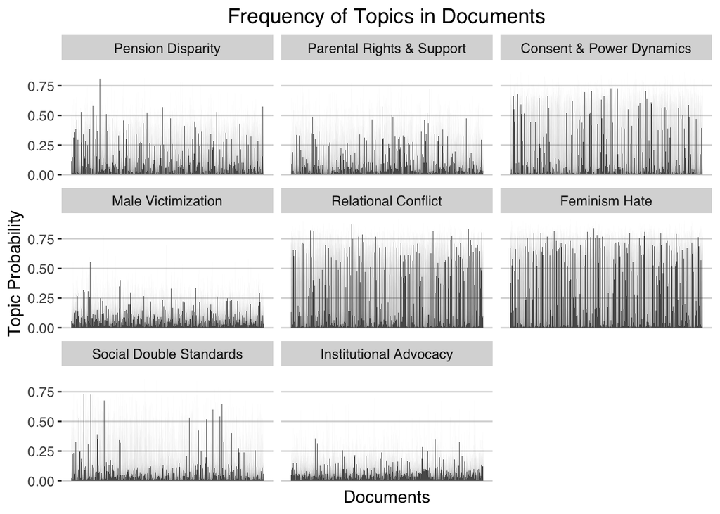

```r
doc_topics_tidy <- melt(doc.topics)

colnames(doc_topics_tidy) <- c("Document_ID", "Topic_ID", "Frequency")

doc_topics_tidy$Topic_Label <- case_when(
  doc_topics_tidy$Topic_ID == 1 ~ "Pension Disparity",
  doc_topics_tidy$Topic_ID == 2 ~ "Parental Rights & Support",
  doc_topics_tidy$Topic_ID == 3 ~ "Consent & Power Dynamics",
  doc_topics_tidy$Topic_ID == 4 ~ "Male Victimization",
  doc_topics_tidy$Topic_ID == 5 ~ "Relational Conflict",
  doc_topics_tidy$Topic_ID == 6 ~ "Feminism Hate",
  doc_topics_tidy$Topic_ID == 7 ~ "Social Double Standards",
  TRUE ~ "Institutional Advocacy"
)

doc_topics_tidy$Topic_Label <- ordered(doc_topics_tidy$Topic_Label, levels = c(
  "Pension Disparity",
  "Parental Rights & Support",
  "Consent & Power Dynamics",
  "Male Victimization",
  "Relational Conflict",
  "Feminism Hate",
  "Social Double Standards",
  "Institutional Advocacy"
))

ggplot(data = doc_topics_tidy, aes(x = Document_ID, y = Frequency)) +
  geom_col(width = 1) +
  facet_wrap(~Topic_Label) +
  ylab("Topic Probability") +
  xlab("Documents") +
  ggtitle("Frequency of Topics in Documents") +
  theme_hc() +
  theme(
    plot.title = element_text(hjust = 0.5),
    axis.text.x = element_blank(),
    axis.ticks.x = element_blank()
  )
```

**Relational Conflict** and **Feminism Hate** emerge as the most dominant and pervasive themes, maintaining consistently higher probabilities across a larger volume of documents than any other category. These topics represent the core of the discourse, characterized by dense and frequent activity throughout the dataset.

In contrast, **Male Victimization** and **Institutional Advocacy** show significantly lower overall frequency, appearing as specialized or niche subjects that only occasionally reach high probability in specific texts. Consent & Power Dynamics also demonstrates high-intensity spikes, suggesting that while it may not be as constant as the primary ideological themes, it remains a frequent and significant point of focus.

#### Frequency of Topic Over Time

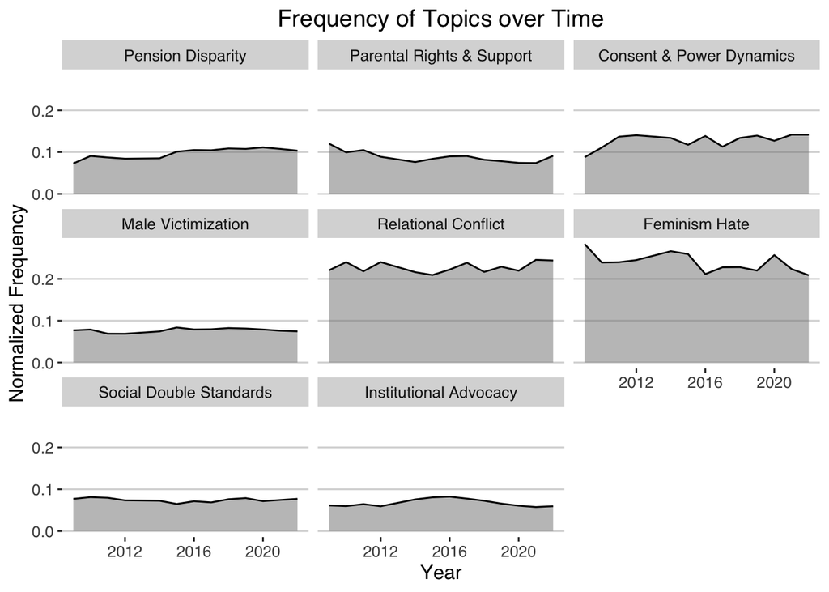

```r
doc_topics_tidy$year <- posthatespeech$year[doc_topics_tidy$Document_ID]

data1 <- doc_topics_tidy %>%

  filter(year != 2013) %>%

  group_by(year, Topic_Label) %>%
  summarise(val_per_year = sum(Frequency), .groups = "drop") %>%

  group_by(year) %>%
  mutate(tot_year = sum(val_per_year)) %>%
  ungroup() %>%

  mutate(norma_val = val_per_year / tot_year) %>%
  mutate(norma_val = replace_na(norma_val, 0))

ggplot(data1, aes(x = year, y = norma_val)) +
  geom_area(fill = "grey50", alpha = 0.5) +
  geom_line(color = "black") +
  facet_wrap(~Topic_Label) +
  ylab("Normalized Frequency") +
  xlab("Year") +
  ggtitle("Frequency of Topics over Time") +
  theme_hc() +
  theme(plot.title = element_text(hjust = 0.5))
```

## Conclusion

Addressing research questions and hypotheses:

- RQ1 & H1: supported, hate-speech-labeled content is consistently present and commonenough to be considered a structural part of the subreddit’s discourse.
- RQ2& H2-H3: for the most part, the results are consistent with what past research describes: many hate-speech posts follow common manosphere frames (misandry, feminism having too much power, distrust in feminist narratives) and focus on classic men’s rights issues like custody/child support and debates around education, violence, and sex. At the same time, some posts are written more like policy or activism reports, which may appear less openly hostile when you read them on their own.
- RQ3: hate-speech subset includes both explicitly anti-feminist & grievance-heavy posts andless hostile posts that communicate in terms of equality/rights. In practice, though, they seem to often cover the same issues: what changes is the tone and wording.

As for the main limitation of our study, we have aknowledge that the boundary between grievance, critique, and hate is genuinely hard to operationalize, and the classifier ultimatelyrelies on gender/ideology keywords, which can lead to flagging of non-hateful but “charged” debate as hate speech.

Overall, the approach that we used allowed us to detect posts containing hate speech at a large scale, and then see what people talk about inside that subset. The main themes are conflict around feminism, relationship problems, reproduction and child support, consent/sexual politics, and complaints about institutions treating men unfairly, and the balance between these themes changes over time (consent/dating talk grows anti-feminist hostility decreases a little). If this study were extended, the most useful next steps would thenbe to clearly separate explicit vs implicit misogyny, sample more of the borderline cases for manual checking, and compare r/MensRights to similar subreddits to see what could bespecific to this community.

## Gen AI Use

Generative AI (ChatGPT and Gemini) was used in this project in accordance with KU Leuven’s guidelines on the responsible use of AI in education and research. The tool supported the research process by assisting with the clarification of coding guidelines and by helping to improve the clarity, structure, and academic style of the written report. Particularly the GenAI helped for regular expressions for the preprocess and the creation of a cross validation function for Naive Bayse. All conceptual decisions, including the research design, development of the coding scheme, interpretation of results, and formulation of conclusions, were made exclusively by the authors. All AI-assisted outputs were critically reviewed, edited, and validated by the research team to ensure accuracy, methodological soundness, and full academic responsibility.

## References

- Chang, W. (2022). The monstrous-feminine in the incel imagination: Investigating the representation of women as “femoids” on /r/Braincels. Feminist Media Studies, 22(2), 254–270. https://doi.org/10.1080/14680777.2020.1804976
- ElSherief, M., Ziems, C., Muchlinski, D., Anupindi, V., Seybolt, J., De Choudhury, M., & Yang, D. (2021). Latent hatred: A benchmark for understanding implicit hate speech. *arXiv preprint arXiv:2109.05322*.
- Ging, D. (2019). Alphas, Betas, and Incels: Theorizing the Masculinities of the Manosphere. Men and Masculinities, 22(4), 638–657. https://doi.org/10.1177/1097184X17706401
- Landis JR, Koch GG. The measurement of observer agreement for categorical data. Biometrics. 1977 Mar;33(1):159-74. PMID: 843571.
- Messner, M. A. (2016). Forks in the Road of Men’s Gender Politics: Men’s Rights vs Feminist Allies. International Journal for Crime, Justice and Social Democracy, 5(2), Article 2. https://doi.org/10.5204/ijcjsd.v5i2.301
- Strathern, Wienke & Pfeffer, Juergen. (2023). Identifying Different Layers of Online Misogyny. 10.36190/2023.54.

## Appendices

**Appendix A : Model trainings for each Variants of Preprocessing**

https://drive.google.com/file/d/1Tn1KoLDmVc-cpas7spg0R8EBFLis8PNJ/view?usp=sharing

**Appendix B : Labelled Dataset**

https://docs.google.com/spreadsheets/d/10cqaOGRM3aZ7M5HLa48X988VKxuYMpbP/edit?usp=sharing&ouid=108179007286731714531&rtpof=true&sd=true

**Appendix C: Validation Dataset**

https://drive.google.com/file/d/19SGJqQvFKZ27ajDVZdqVzLGmDUOwlgm6/view?usp=sharing